# Cohort Population Analysis with R

Summer One Week Challenge 1

Shusei Yokoi

8/14/2020

# Cohort Analysis

**“Cohort analysis is a subset of behavioral analytics that takes the data from a given data set (e.g. an EMRS, an e-commerce platform, web application, or online game) and rather than looking at all users as one unit, it breaks them into related groups for analysis. These related groups, or cohorts, usually share common characteristics or experiences within a defined time-span.” - wikipedia**

### Objectives

Objective here is to perform cohort analysis on population in Japan using R, and to estimate future population based on the analysis.

### Getting and Cleansing Data

```r
population = read_excel('05016.xls')
population = population %>%
  select(3,5,seq(12,67,7)) %>%
  slice(-c(1,2,4:10, 133:144))

population_each = population %>%
  slice(-c(seq(3,117,6))) %>%
  slice(-c(1:2)) %>%
  slice(-101) %>%
  select(-...3)
colnames(population_each) = c('age',population[1,c(3:10)])
colnames(population_each) = c('age','year_1920','year_1960','year_1970','year_1980','year_1990','year_1995','year_2000','year_2005')
population_1990to2005 = population_each %>%
  select('age','year_1990','year_1995','year_2000','year_2005')

population_1990to2005 = population_1990to2005 %>%
  mutate(year_1990 = as.numeric(population_1990to2005$year_1990)) %>%
  mutate(year_1995 = as.numeric(population_1990to2005$year_1995)) %>%
  mutate(year_2000 = as.numeric(population_1990to2005$year_2000)) %>%
  mutate(year_2005 = as.numeric(population_1990to2005$year_2005))


DT::datatable(head(population_each,100),
              rownames = FALSE,
              options = list(
                pageLength = 10,
                pageLength = c(10,20,30,40,50)))
```

| age | year_1920 | year_1960 | year_1970 | year_1980 | year_1990 | year_1995 | year_2000 | year_2005 |
| --- | --- | --- | --- | --- | --- | --- | --- | --- |
| ０ | 1877543 | 1599948 | 1898242 | 1586504 | 1213685 | 1191578 | 1171652 | 1056800 |
| １ | 1392988 | 1619004 | 1883710 | 1636235 | 1260478 | 1201008 | 1166160 | 1091316 |
| ２ | 1387685 | 1573664 | 1839328 | 1706055 | 1301517 | 1185263 | 1192157 | 1115649 |
| ３ | 1391499 | 1536505 | 1843664 | 1749163 | 1343438 | 1208065 | 1189303 | 1149450 |
| ４ | 1408000 | 1635707 | 1442620 | 1837459 | 1373779 | 1209340 | 1184826 | 1164872 |
| ５ | 1372928 | 1735222 | 1789278 | 1927082 | 1438361 | 1231252 | 1204133 | 1182977 |
| ６ | 1403933 | 1727533 | 1679517 | 2033501 | 1488041 | 1269637 | 1207742 | 1179736 |
| ７ | 1382121 | 1839369 | 1637334 | 2067213 | 1504285 | 1311187 | 1188966 | 1193349 |
| ８ | 1377788 | 1950937 | 1587147 | 2025049 | 1508173 | 1349829 | 1210282 | 1188871 |
| ９ | 1320150 | 2086080 | 1574060 | 1979189 | 1527697 | 1378766 | 1210666 | 1183562 |

[output cut: 90 more lines]

### Creating Cohort Model

After the data cleaning, I am ready to create a cohort model. Since the census was done every 5 years, 5 years old children in 1990 represent 10 years old children in the next census. I will create a cohort group of each age and move each column by 5, 10, 15 rows because I wan to population change. For example, I would like to know how many babies who were 0 years old in 1990 survived in 1995; by this time babies were 5 years old. the *lead* function did a good job of helping me shipping the dataset.  
The plot below showes taile of the cohort dataset. Cohort 84; 15792 of people who were 84 years old at 1990 are still alive at 2005; they are 99 (84+15) years old in 2005!.

*Note: people who are over 100 years old was not included in this analysis*

```r
cohort_1990to2005 = population_1990to2005 %>%
  mutate(year_1995 = as.numeric(lead(population_each$year_1995,5)))%>%
  mutate(year_2000 = as.numeric(lead(population_each$year_2000,10)))%>%
  mutate(year_2005 = as.numeric(lead(population_each$year_2005,15)))%>%
  rename( 'age_at_1990' = 'age')


knitr::kable(tail(cohort_1990to2005,16))
```

| age_at_1990 | year_1990 | year_1995 | year_2000 | year_2005 |
| --- | --- | --- | --- | --- |
| 84 | 247453 | 132879 | 54520 | 15792 |
| 85 | 226914 | 113845 | 42429 | NA |
| 86 | 189128 | 88487 | 29798 | NA |
| 87 | 168327 | 71960 | 21687 | NA |
| 88 | 137602 | 54030 | 14648 | NA |
| 89 | 111079 | 39480 | 9926 | NA |
| 90 | 82892 | 26361 | NA | NA |
| 91 | 60798 | 17496 | NA | NA |
| 92 | 47454 | 12536 | NA | NA |
| 93 | 33525 | 7742 | NA | NA |
| 94 | 23250 | 4809 | NA | NA |
| 95 | 15613 | NA | NA | NA |
| 96 | 9943 | NA | NA | NA |
| 97 | 6348 | NA | NA | NA |
| 98 | 3962 | NA | NA | NA |
| 99 | 2356 | NA | NA | NA |

### Surviving Rate

Next, I would like to know 5-year-surviving rate for each ages. Thanks to https://stuifbergen.com/2018/03/cohort-analysis-with-snowplow-and-r/ for giving me clean and easy guideline to manage that. After some editing, I got *cohort_1990to2005_pct* that represent 5-year-surviving rate for each ages.

```r
cohort_1990to2005_pct = data.frame(
  cohort = cohort_1990to2005$'age_at_1990',
  pop_1990 = cohort_1990to2005$year_1990, # pop at 1990
  round(cohort_1990to2005[,3:ncol(cohort_1990to2005)] / cohort_1990to2005[["year_1990"]],3)*100 #  divide eahc pop by pop_1990
)
DT::datatable(head(cohort_1990to2005_pct,100),
              rownames = FALSE,
              options = list(
                pageLength = 8
                ))
```

| cohort | pop_1990 | year_1995 | year_2000 | year_2005 |
| --- | --- | --- | --- | --- |
| ０ | 1213685 | 101.4 | 102.1 | 101.7 |
| １ | 1260478 | 100.7 | 100.1 | 101 |
| ２ | 1301517 | 100.7 | 101 | 100.9 |
| ３ | 1343438 | 100.5 | 100.7 | 101 |
| ４ | 1373779 | 100.4 | 100.3 | 101.2 |
| ５ | 1438361 | 100.1 | 100.3 | 100.3 |
| ６ | 1488041 | 100.2 | 100.4 | 98.9 |
| ７ | 1504285 | 100.2 | 100.4 | 98.5 |
| ８ | 1508173 | 100.2 | 100.1 | 97.4 |
| ９ | 1527697 | 100.1 | 100.2 | 97.3 |

[output cut: 90 more lines]

*Note: It is weird to have 100+% of surviving rate. I assume infant death rate is very low and some immigrants are causing 100+% of surviving rate.*

### Visualization

Now it’s time to visualize it for better understanding. Basically, what I have done here is concatenate dataset that I am interested in, and make a copy of data frame as matrix. I would like to see full size of the cohort table, but since I have 100 rows, it will get messy when its plotted.  
Here I choose cohort 64 to 94.

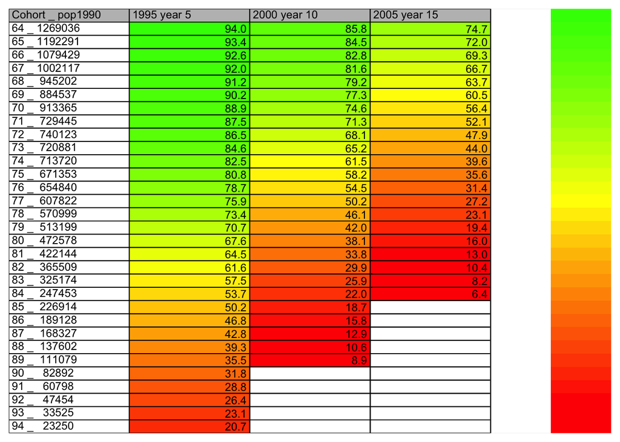

```r
temp = as.matrix(cohort_1990to2005_pct[65:95,])
rownames(temp) = as.character(paste(temp[,1],'_',temp[,2]))
temp = temp[,3:ncol(temp)]
colnames(temp) = paste( seq(1995,2005,5),'year', seq(5,15,5))


plot.table(temp,smain = 'Cohort _ pop1990', highlight = TRUE, colorbar = TRUE)
```

### Estimation

From the surviving rate, I am ready to estimate population change in 2010.  
First, get survival rate thru 2000 to 2005  
Second, multiple that by population of 2005  
Third, Cbind to the existing cohort table and See what you get!

```r
survival_pct_2000to2005 = cohort_1990to2005[,5]/cohort_1990to2005[,4]
colnames(survival_pct_2000to2005) = 'survival_rate'

pop2005 = cohort_1990to2005 %>%
  select(year_2005) %>%
  transmute(year_15 = as.numeric(cohort_1990to2005$year_2005))
estpop_2010 = data.frame(round(survival_pct_2000to2005 * pop2005))

colnames(estpop_2010) = c('Est_year_2010')
final_cohort = cbind(cohort_1990to2005,estpop_2010)
DT::datatable(head(final_cohort,100),
              rownames = FALSE,
              options = list(
                pageLength = 10
                ))
```

| age_at_1990 | year_1990 | year_1995 | year_2000 | year_2005 | Est_year_2010 |
| --- | --- | --- | --- | --- | --- |
| ０ | 1213685 | 1231252 | 1239516 | 1234174 | 1228855 |
| １ | 1260478 | 1269637 | 1262345 | 1273076 | 1283898 |
| ２ | 1301517 | 1311187 | 1314403 | 1313462 | 1312522 |
| ３ | 1343438 | 1349829 | 1352506 | 1357096 | 1361702 |
| ４ | 1373779 | 1378766 | 1377842 | 1390572 | 1403420 |
| ５ | 1438361 | 1439250 | 1442928 | 1442590 | 1442252 |
| ６ | 1488041 | 1490285 | 1494054 | 1471327 | 1448946 |
| ７ | 1504285 | 1506868 | 1509872 | 1481329 | 1453326 |
| ８ | 1508173 | 1511715 | 1510429 | 1469413 | 1429511 |
| ９ | 1527697 | 1529687 | 1530882 | 1485939 | 1442315 |

[output cut: 90 more lines]

# Test the Model

Hmm.. How did I do?  
I don’t know!  
So let’s test it with actual population of 2010!

```r
actual_pop2010 = tibble(c(1045975,1045417,1074194,1069540,1061622,1058489,1098856,1117316,1147733,1163267,1175275,1176598,1195772,1190404,1182986,1218766,1226037,1202514,1215892,1200148,1219150,1249329,1288282,1321513,1348159,1404312,1449555,1469956,1475731,1494147,1561305,1600983,1669936,1712263,1797010,1880293,1981982,2017073,1978648,1928353,1874292,1846761,1807649,1803149,1410014,1744172,1632518,1594519,1542921,1518986,1532059,1559648,1519884,1478697,1554211,1608361,1611287,1713738,1809889,1920459,2066423,2261917,2244319,2132584,1332006,1426865,1732916,1674435,1714817,1661140,1500984,1298743,1376960,1400129,1386486,1308845,1217357,1197125,1143547,1074139,990275,932127,868554,801946,743362,648870,547394,472872,411987,351465,316840,219756,192863,160027,132221,97626,77372,55845,39826,26087))
actual_pop2010 = lead(actual_pop2010, 19) # shift dataset as you needed
# Here, I need 19 years old as cohort 0. Since 0 years old in 1990 is 19 years old in 2010.

# Get residuals

diff = actual_pop2010 - final_cohort$Est_year_2010
diff_pct = diff/actual_pop2010
result = cbind(actual_pop2010, final_cohort$Est_year_2010, diff, abs(diff_pct)*100)
colnames(result) = c('actual','estimate','diff','diff_pct(%)')


DT::datatable(head(result,100),
              rownames = FALSE,
              options = list(
                pageLength = 10,
                pageLength = c(10,20,30,40,50)))
```

| actual | estimate | diff | diff_pct(%) |
| --- | --- | --- | --- |
| 1200148 | 1228855 | -28707 | 2.39195499221763 |
| 1219150 | 1283898 | -64748 | 5.31091334126235 |
| 1249329 | 1312522 | -63193 | 5.05815521772087 |
| 1288282 | 1361702 | -73420 | 5.69906278283792 |
| 1321513 | 1403420 | -81907 | 6.19797156743823 |
| 1348159 | 1442252 | -94093 | 6.97936964408501 |
| 1404312 | 1448946 | -44634 | 3.17835352827577 |
| 1449555 | 1453326 | -3771 | 0.260148804288213 |
| 1469956 | 1429511 | 40445 | 2.75144290033171 |
| 1475731 | 1442315 | 33416 | 2.26436931934072 |

[output cut: 90 more lines]

To sum up, distribution of the percentage error is below.  
Most of error stays in less than 10%, but some estimate for older generation causing bigger error.

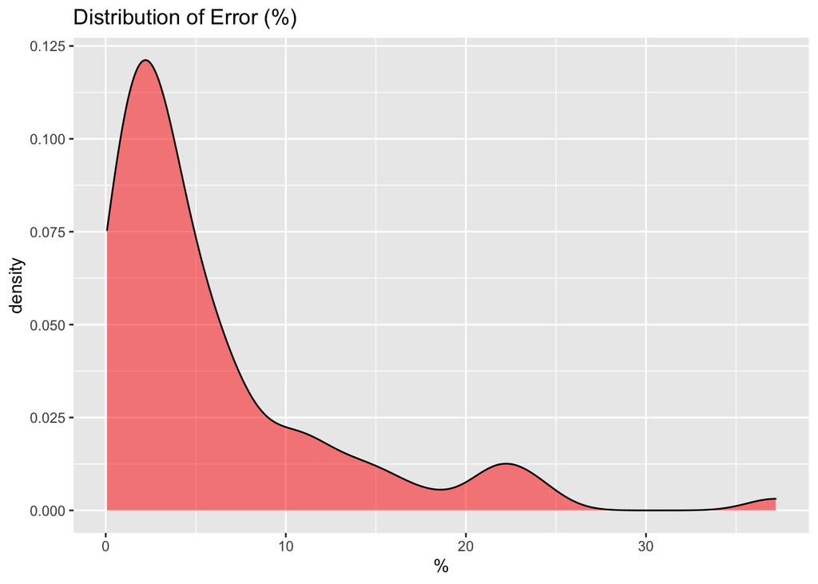

```r
ggplot(result, aes(x=`diff_pct(%)`))+
   geom_density(alpha=.5, fill='red') +
  xlab('%') +
  labs(title = 'Distribution of Error (%)')
```

**Error summary**

```r
summary(result$diff_pct)
```

```
##     Min.  1st Qu.   Median     Mean  3rd Qu.     Max.     NA's
##  0.07355  1.79721  3.39036  6.03686  7.44772 37.19849       19
```